# Sonja PhraseFlow

Author: Sonja Sahebzad  
Utrecht, the Netherlands | September 27, 2026

Your next word,  
in your language.

Twelve selectable languages.  
A compact R app with measured results and a clear user guide.

[Open the illustrated user guide](https://sonja242.github.io/data-science-capstone-swiftkey/phraseflow-guide.html)

Sonja Projects · Version 1.4  
English is unchanged. Additional languages are experimental.  
[Open the live app](https://sonjasahebzad.shinyapps.io/sonja-next-word/)

### The prediction model

### A separate model for each language

English, German, Finnish and Russian use course-corpus text. Eight added languages use Tatoeba example sentences.

### Recent words guide the next word

A five-gram model uses up to four recent units. Kneser-Ney smoothing blends longer and shorter patterns when evidence is sparse.

### Text processing follows the script

Chinese uses ICU word segmentation. Korean retains space-delimited units. Accents, Cyrillic and Hindi vowel signs are preserved.

**12**selectable languages**CPU**native R inference

Lazy loading and a bounded cache.  
No external prediction API.

Methods: [Chen & Goodman](https://aclanthology.org/P96-1041/); [ICU](https://unicode-org.github.io/icu/userguide/boundaryanalysis/). Additional data: [Tatoeba contributors, CC BY 2.0 FR](https://tatoeba.org/en/downloads).

### Using the app and the guide

1. Choose a language and enter a phrase.
2. Finish a word, then pause or select **Predict next word**.
3. Click a suggestion to keep writing.

Chinese does not require spaces. Choose **5, 10 or 20 words**. Extra buttons offer short endings from matching training phrases.

[**Open the illustrated user guide**](https://sonja242.github.io/data-science-capstone-swiftkey/phraseflow-guide.html)

The **User guide / Handleiding** button explains both features. Short endings remain experimental; the accuracy charts measure the word model.

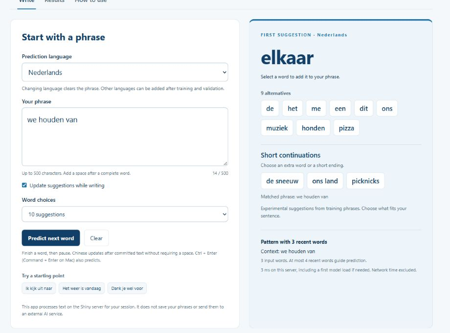

### English performance

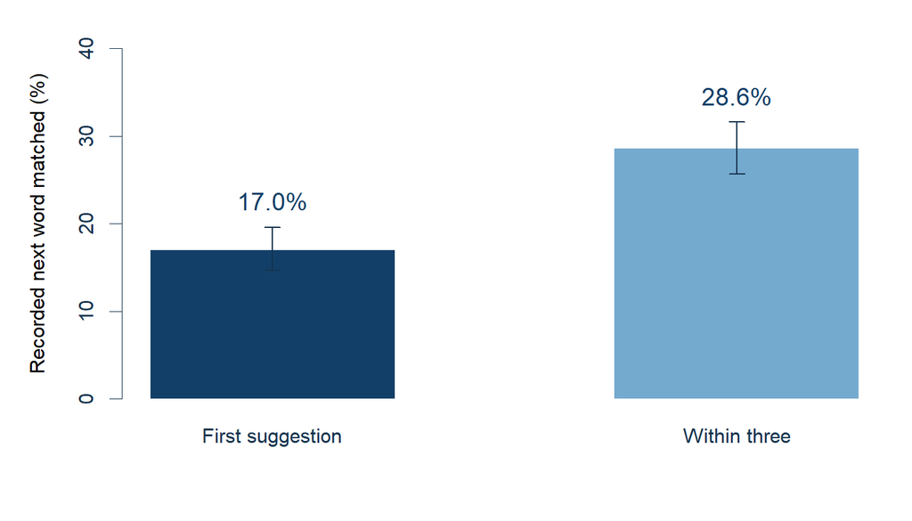

### 900 unseen examples

First: **153/900**  
Within three: **257/900**

Whiskers show 95% sampling intervals. They do not express certainty for one suggestion.

### Fast local lookup

Archived median: **0.58 ms** for three suggestions. Network and display add time.

Archived English evaluation; test examples were not reopened. All 900 received a suggestion. This is availability, not 100% accuracy. Individual confidence is not calibrated.

### Additional language results

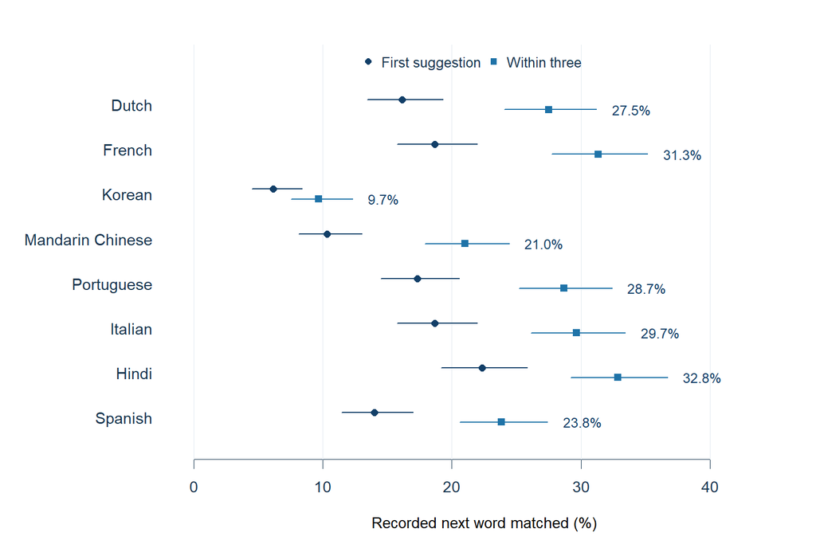

### 600 cases per language

Held-out Tatoeba sentences. Settings were fixed before evaluation.

Different data, training sizes and word units: these are separate results, not a language ranking.

### Next improvement

Better representative data, native-speaker review and a compact model using more sentence context.

Lines show Wilson 95% sampling intervals. Similar sentence templates may remain; everyday-message performance is untested. [Full results, earlier prototypes, timing and instructions](https://sonja242.github.io/data-science-capstone-swiftkey/phraseflow-guide.html) · [Data credits](https://sonja242.github.io/data-science-capstone-swiftkey/phraseflow-data-credits.html). Sonja Sahebzad · Utrecht, the Netherlands.